# Assignment0_ThierryMartin

Thierry Martin

January 31, 2017

##### ToDo 1:

Result: 10

Result: 10

#### ToDo 3:

Result: 28

#### ToDo 4:

Result:

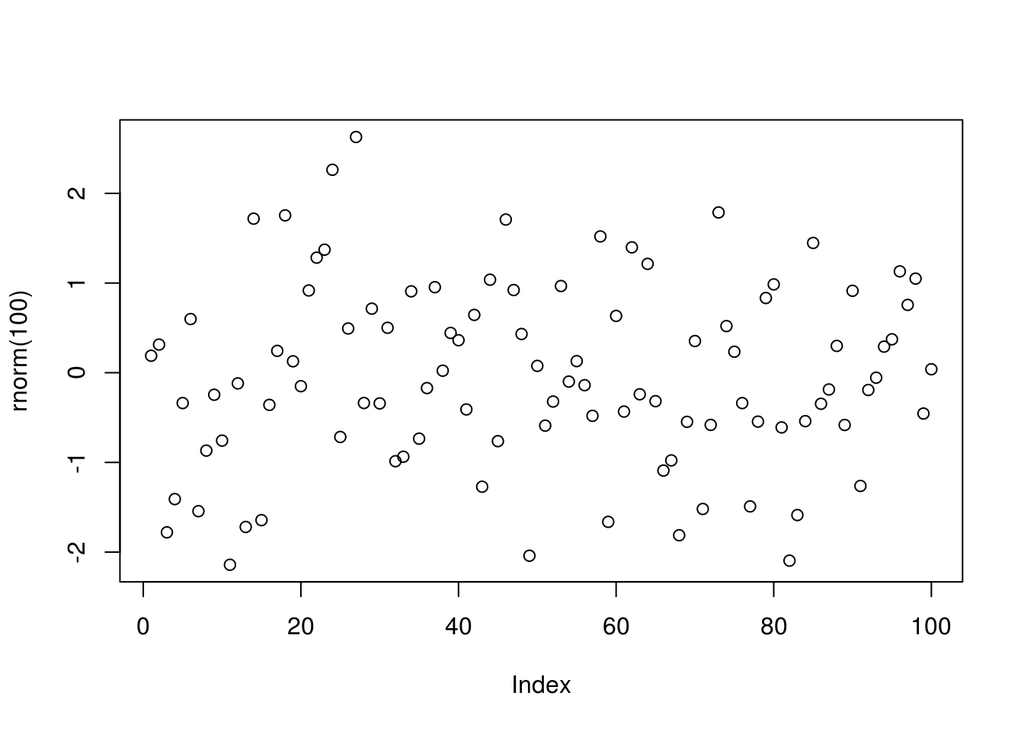

```r
plot(rnorm(100))
```

Comment: To make the plot display using R Markdown you need to add {r} before the plot code, you can even add the desired with and things of that order to make the plot display the way you desire.

#### ToDo 5:

Result: /usr/lib/R/library/base/help/MathFun

#### ToDo 6:

Result: r lapply(1:10, function(n)source(“firstscript.R”)$value)

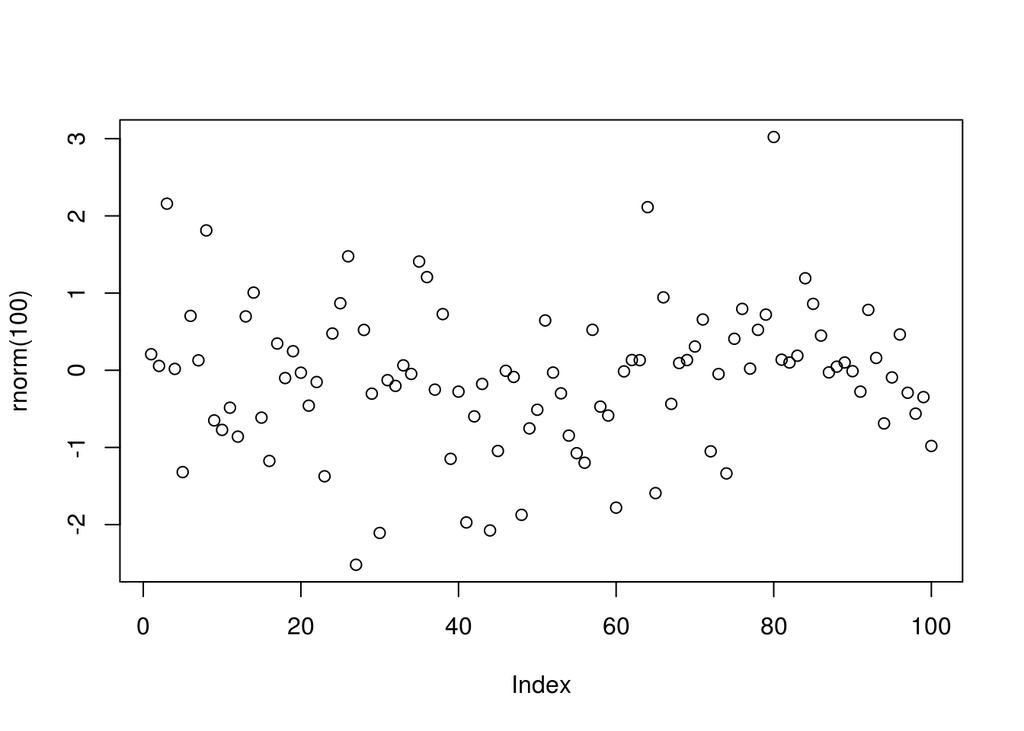

```r
plot(rnorm(100))
```

Comment: This scrip must exits and R needs to have access to the script for it to run, therefore I made the appropriate r code, but the code is only displayed, it is not the actual running code.

#### ToDo 7:

Result: 31, 32, 33, 34, 35, 36, 37, 38, 39, 40, 41, 42, 43, 44, 45, 46, 47, 48, 49, 50, 51, 52, 53, 54, 55, 56, 57, 58, 59, 60

Comment: I am having trouble displaying the Q matrix in R Markdown, however the code to create Q is in the R Markdown document, Q= matrix(P,ncol = 5, nrow = 6). I can make this work in the Console however by simply entering Q.

#### ToDo 8:

Result:

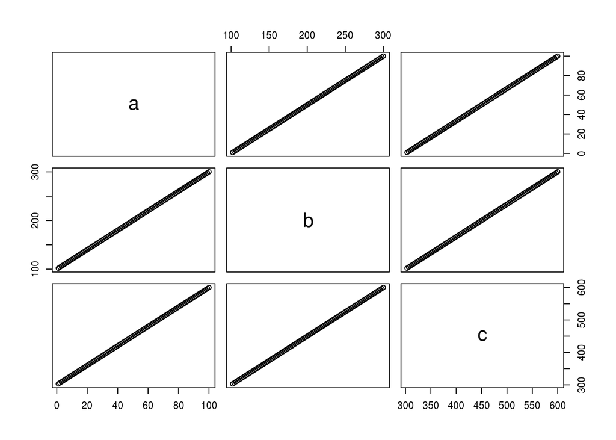

```r
x1=seq(from=1, to=100, by=1)
x2=seq(from=101, to=200, by=1)
x3=seq(from=201, to=300, by=1)
t= data.frame(a=x1,b=x1+x2,c=x1+x2+x3)
plot(t)
```

#### ToDo 9:

Result:

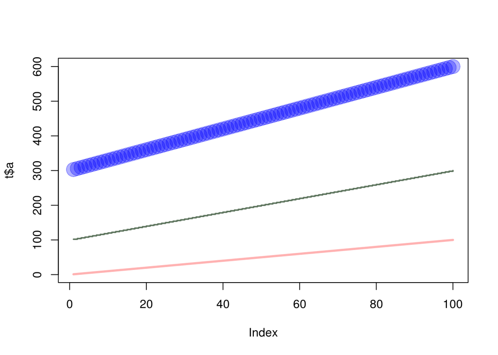

```r
plot(t$a, type="l", ylim=range(t),lwd=3, col=rgb(1,0,0,0.3))
lines(t$b, type="s", lwd=2,col=rgb(0.3,0.4,0.3,0.9))
points(t$c, pch=20, cex=4,col=rgb(0,0,1,0.3))
```

#### ToDo 10:

Result: 0.2256574

Comment: It is possible to receive NaNs or an error because of the NaNs result, it is produced when the resulting value is negative, run Knit again in R Markdown t’ill you receive a result.

#### ToDo 11:

Result: 15, 20, 25

#### ToDo 12:

Comment: This code is simply displayed, it works in the Console, but I cant seem to make it work in R Markdown.

#### ToDo 13

Result:

5, 10, 15, 20, 0.5, 0.6, 0.7, 0.8, 0.9, 1, 1.1, 1.2, 1.3, 1.4, 1.5, 1.6, 1.7, 1.8, 1.9, 2, 2.1, 2.2, 2.3, 2.4, 2.5, 2.6, 2.7, 2.8, 2.9, 3, 3.1, 3.2, 3.3, 3.4, 3.5, 3.6, 3.7, 3.8, 3.9, 4, 4.1, 4.2, 4.3, 4.4, 4.5, 4.6, 4.7, 4.8, 4.9, 5, 5.1, 5.2, 5.3, 5.4, 5.5, 5.6, 5.7, 5.8, 5.9, 6, 6.1, 6.2, 6.3, 6.4, 6.5, 6.6, 6.7, 6.8, 6.9, 7, 7.1, 7.2, 7.3, 7.4, 7.5, 7.6, 7.7, 7.8, 7.9, 8, 8.1, 8.2, 8.3, 8.4, 8.5, 8.6, 8.7, 8.8, 8.9, 9, 910, 920, 930, 940, 950, 960, 970, 980, 990, 1000